# project3

## How the World Has Aged: A Study of Life Expectancy Trends

*Derek Miller*  
*University of Maryland, College Park*

This report investigates global trends in life expectancy over time using a Gapminder dataset that captures demographic and life expectancy information from a wide range of countries. The primary goal is to determine whether life expectancy has generally increased across the decades and to explore the shape and consistency of this trend.

To conduct this analysis, the Python libraries Pandas (for data manipulation), NumPy (for numerical operations like reshaping arrays), and Matplotlib and Seaborn (for visualization) are used to uncover patterns in the data through scatterplots and other graphical tools. Scikit-Learn is used for fitting linear regression models and estimating coefficients and Statsmodels is used for performing regression with formula syntax and providing detailed statistical summaries. In addition to presenting the results, the report also explains how the underlying Python code works, detailing the steps taken to load, transform, and visualize the data to support each stage of the analysis. By visualizing these trends and explaining the technical process, the report aims to shed light on global health improvements, identify regional disparities, and highlight any anomalies that stand out across the years.

### Dataset Description

The dataset used in this analysis is a curated subset of the widely known Gapminder dataset. It includes key demographic information for countries around the world, recorded at five-year intervals from 1952 to 2007. This dataset offers a comprehensive look at how life expectancy, population size, and economic development have evolved globally, making it well-suited for examining long-term public health trends.

| Column Name | Data Type | Description |
| --- | --- | --- |
| `country` | string | The name of the country where the data was recorded. |
| `continent` | string | The continent to which the country belongs (e.g., Asia, Europe). |
| `year` | int | The year of the observation, sampled in five-year intervals from 1952 to 2007. |
| `lifeExp` | float | Life expectancy at birth (in years) for that country and year. |
| `pop` | int | Total population of the country in that year. |
| `gdpPercap` | float | Gross Domestic Product per capita (inflation-adjusted income per person). |

```python
# Necessary Imports
import pandas as pd
import seaborn as sns
import matplotlib.pyplot as plt

# Ignore warning messages
import warnings
warnings.filterwarnings("ignore", message=".*tight_layout.*")

# Data Imports
data = pd.read_csv("gap.tsv", sep='\t')
data.head()
```

|  | country | continent | year | lifeExp | pop | gdpPercap |
| --- | --- | --- | --- | --- | --- | --- |
| 0 | Afghanistan | Asia | 1952 | 28.801 | 8425333 | 779.445314 |
| 1 | Afghanistan | Asia | 1957 | 30.332 | 9240934 | 820.853030 |
| 2 | Afghanistan | Asia | 1962 | 31.997 | 10267083 | 853.100710 |
| 3 | Afghanistan | Asia | 1967 | 34.020 | 11537966 | 836.197138 |
| 4 | Afghanistan | Asia | 1972 | 36.088 | 13079460 | 739.981106 |

### Scatterplot: Life Expectancy over Time

Creating a scatterplot of life expectancy over time is important because it visually reveals trends and patterns in how life expectancy has changed across years. This helps identify overall increases, fluctuations, or anomalies that might warrant further analysis.

How the Code Works:

- To make a scatterplot of life expectancy across time, we first need to identify the dataset were using, along with what columns represent the independent variable and dependent variable. In this case, the DataFrame 'data' is our dataset, it's column 'year' will represent time (the indepedent variable x), and it's column 'lifeExp' will represent life expectancy (the dependent variable y).
- Next, we make use of Seaborn's 'scatterplot' method, which takes in three arguments: data (we'll pass in the DataFrame 'data' for this value), 'x' (we'll pass in the column 'year' for this value), and 'y' (we'll pass in the column 'lifeExp' for this value)
- Calling this function with the specified arguments mentioned above will display the desired scatterplot.
- Use Matplotlib's xlabel(), ylabel(), and title() functions to label the axes and add a title to the plot.
- Finally, call plt.show() to render and display the scatterplot.

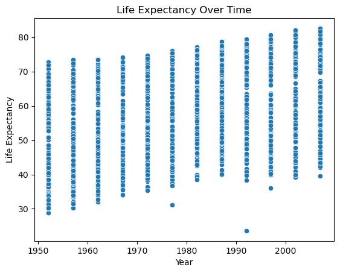

```python
sns.scatterplot(data=data, x='year', y='lifeExp')
plt.xlabel("Year")
plt.ylabel("Life Expectancy")
plt.title("Life Expectancy Over Time")
plt.show()
```

### Scatterplot Assessment:

#### Overall Trend in Life Expectancy Over Time

When looking at the distribution of data points across the years, there is a general increasing trend for life expectancy across time. This is evident because, in general, as 'year' increases, so does 'lifeExp'. If I was to add a regression line to this plot, the slope of the line would also appear to be increasing.

#### Is the Life Expectancy Trend Linear?

When looking at the plot, there are very few outliers (some do exist, but not many) and most data points for each year seem to clustered within a certain range. For example, for 1952, it appears all the data points are clustered between the ages of 73 roughly and 29 roughly. Within these ranges (for each year, respectively), it can be seen that the many data points overlap each other, and there's rarely any whitespace across the point distribution for any specific year. Additionally, It appears as if the upper bound and lower bound for each cluster of points increases a little bit each year (for the most part). Thus, it appears as if the cluster of data points is shifted up a little with each subsequent year, giving off the impression that there's a constant positive slope for the trend line. For these reasons, the trend appears to be linear.

### Violin Plot: Life Expectancy Over Year

A violin plot of life expectancy over the years is important because it shows the distribution and variability of life expectancy data at each time point, giving insight into the range and density of values beyond just the average. This helps highlight changes in data spread and potential outliers across time.

How the Code Works:

- To make a violin plot of life expectancy across time, we first need to identify the dataset were using, along with what columns represent the independent variable and dependent variable. In this case, the DataFrame 'data' is our dataset, it's column 'year' will represent time (the indepedent variable x), and it's column 'lifeExp' will represent life expectancy (the dependent variable y).
- Next, we make use of Seaborn's 'violinplot' method, which takes in three arguments: data (we'll pass in the DataFrame 'data' for this value), 'x' (we'll pass in the column 'year' for this value), and 'y' (we'll pass in the column 'lifeExp' for this value)
- Calling this function with the specified arguments mentioned above will display the desired violin plot.
- Use Matplotlib's xlabel(), ylabel(), and title() functions to label the axes and add a title to the plot.
- Finally, call plt.show() to render and display the scatterplot.

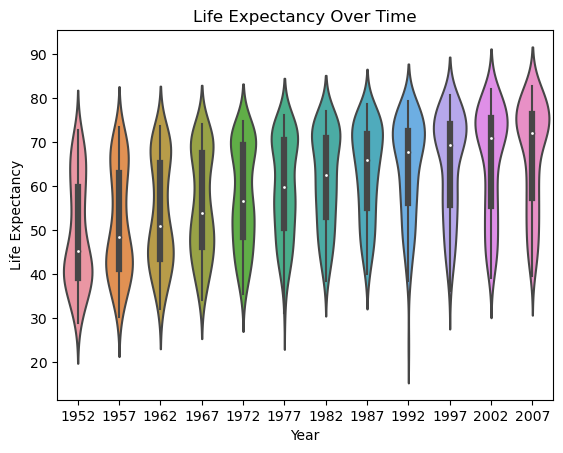

```python
sns.violinplot(data=data, x='year', y='lifeExp')
plt.xlabel("Year")
plt.ylabel("Life Expectancy")
plt.title("Life Expectancy Over Time")
plt.show()
```

### Violin Plot Assessment:

#### Distribution of Life Expectancy Across Countries by Year: Skewness, Symmetry, and Modality

- In 1952, there appears to be a high cluster of data points around lower life expectancy values, and as life expectancy increases the violin shape is thinner (signifying less clustering). This suggests a longer tail on the right side of these violin plots, indicating a positive skew for this first year. This first violin (for 1952) also appears to be unimodal, since there's only one main cluster (younger ages). Since this mode is not in the middle of the violin plot, this is not symmetric
- From the year 1957 to 1972, there appears to be two main clusters on for each violin, one for younger ages and one for older ages (with a narrower section between each cluster, signfying a smaller amount of data points in between each cluster.) Since there are two main clusters, these plots are not unimodal. However, since these clusters occur on the ends of each violin plot (younger and older ages) with it narrowing in the middle, these plots appear to be more symmetric (generally symmetric). Since the clusters for some of the years within this range aren't perfectly the same shape (1957 for innstance) to say it's completely symmetric would not be true.
- From 1977 to 2007, only one cluster exists, and this cluster represents older ages (higher values). Since more data points are clustered around higher values, and less around the lower values, we can see there's a longer tail on the left side of these violin plots. This indicates a negative skew for these years. Since there's only one cluster, the plots are unimodal for these years, and also not symmetric, since the cluster happens at a tail in each violin plot.

#### Testing for a Relationship Between Year and Life Expectancy

Based on the violin plot, I would reject a null hypothesis of no relationship and accept the alternative hypthesis that suggests a relationship does exist. This is because starting in 1952, most data points are clustered aroung younger ages. As we move from 1952 to 2007, each year we see the cluster around younger ages shrink (data points become more dispersed) and the cluster around older ages grow (data points are more dense, close to one another). We visibly see the median (represented by the white dot inside each violin) increase as year increases, strongly suggesting that life expectancy and year has a positive relationship. Formal statistical tests would be required to confidently reject a null hypothesis of no relationship and confirm the strength and significance of this association.

#### Understanding What Residual Violin Plots Over Time may look like

Residuals are calculated as the difference between actual and predicted life expectancy values. A violin plot of residuals by year would show the distribution of these errors for each year. According to the assumptions of the linear regression model, residuals should be normally distributed with a mean of zero, have constant variance (homoscedasticity), and be independent of one another. If these assumptions hold, each violin should be roughly symmetric, centered around zero, and exhibit a similar spread across years.

In practice, if the linear model systematically underpredicts life expectancy in earlier years (like 1952), we may observe positive median residuals for those years, causing the corresponding violin to be centered above zero. Similarly, if the model overpredicts life expectancy in earlier years, we may observe negative median residuals for those years, causing the corresponding violin to be centered below zero. As the model improves over time, later years might show residuals closer to zero, possibly resulting in a slight downward (upward) trend in the median positions of the violins. The shape and spread of each violin will reflect how prediction errors vary by year, and any visible trends or asymmetries could suggest violations of the model's assumptions.

### Fitting a Linear Regression Model: Life Expectancy vs. Year

Fitting a linear regression model allows us to quantify the relationship between year and life expectancy. By doing this, we can determine whether life expectancy has generally increased over time and estimate the average rate of change per year using the model's slope (coefficient).

How the Code Works:

- Import the necessary libraries and methods (from sklearn.linear_model import LinearRegression)
- Reshape the series representing the year in our dataset to the proper format (Using NumPy's 'reshape()' method). The resulting shape will be a 2d-array. Store this newly formatted ndarray into a variable.
  - NOTE --> This requires taking each element of the year series and storing it inside its own unique list, and storing all those lists inside a list.
- Call LinearRegression() to create a LinearRegression object and store it in a variable called 'lr'.
- Call lr's method 'fit()', which fits a linear model and returns a fitted estimator. The arguments of fit will be 'X', which represents the training data, and 'y', which represent the target values. We'll set 'X' to be equal to data[['year']] because X requires a 2d-array argument. We'll set 'y' to be equal to data['lifeExp'].
  - NOTE --> 'year' is the independent variable and 'lifeExp' is the dependent variable.
- Store the result of 'fit()' in a variable called 'OLS_model'
- Print the Coefficient and Intercept of the fitted estimator

```python
import numpy as np
from sklearn.linear_model import LinearRegression

# Way 1 --> This way is described above
yr = np.array(data['year']).reshape(-1, 1)
lr = LinearRegression()
OLS_model = lr.fit(X=data[['year']], y=data['lifeExp'])

print(OLS_model.coef_)
print(OLS_model.intercept_)
```

```
[0.32590383]
-585.6521874415445
```

#### Average Yearly Increase in Global Life Expectancy

We can figure this out by looking at the coefficient of the linear regression model we found above. To do this, we simply call OLS*model.coef* and print the result. This number ends up being 0.3259.

```python
print(OLS_model.coef_)
```

```
[0.32590383]
```

### Evaluating the Linear Regression Model with Summary Statistics

From here on out, we should calculate some statistics to help determine how good of a fit this model is. To do this, we need to use statsmodels.formula.api

How the Code Works:

- Import 'statsmodels.formula.api' to use the necessary functions (this is a convenient interface for specifying models using formula strings and DataFrames)
- Call the interfaces method 'ols()' to create a model from a formula and a DataFrame object.
- Pass in the appropriate arguments in the proper format:
  - To model life expectancy versus year, pass in the following to formula: "lifeExp ~ year"
    - formula argument is the formula specifying the model.
  - Pass in 'data' for the data argument, as that's the data being used for the model
- This returns the model instance, which we then can call the method 'fit()' on to properly fit the model
- Store the result of 'fit()' in a variable called 'lr'
- Call lr's method 'summary()' which calculates the useful summary statistics that tell us whether or not this is a good fit, print these results.

```python
import statsmodels.formula.api as sm
lr = sm.ols(formula="lifeExp ~ year", data=data).fit()
print(lr.summary())
```

```
                            OLS Regression Results
==============================================================================
Dep. Variable:                lifeExp   R-squared:                       0.190
Model:                            OLS   Adj. R-squared:                  0.189
Method:                 Least Squares   F-statistic:                     398.6
Date:                Sun, 22 Jun 2025   Prob (F-statistic):           7.55e-80
Time:                        20:06:02   Log-Likelihood:                -6597.9
No. Observations:                1704   AIC:                         1.320e+04
Df Residuals:                    1702   BIC:                         1.321e+04
Df Model:                           1
Covariance Type:            nonrobust
==============================================================================
                 coef    std err          t      P>|t|      [0.025      0.975]
------------------------------------------------------------------------------
Intercept   -585.6522     32.314    -18.124      0.000    -649.031    -522.273
year           0.3259      0.016     19.965      0.000       0.294       0.358
==============================================================================
Omnibus:                      386.124   Durbin-Watson:                   0.197
Prob(Omnibus):                  0.000   Jarque-Bera (JB):               90.750
Skew:                          -0.268   Prob(JB):                     1.97e-20
Kurtosis:                       2.004   Cond. No.                     2.27e+05
==============================================================================

Notes:
[1] Standard Errors assume that the covariance matrix of the errors is correctly specified.
[2] The condition number is large, 2.27e+05. This might indicate that there are
strong multicollinearity or other numerical problems.
```

#### Hypothesis Test for Life Expectancy vs. Year Relationship

I reject the null hypothesis of no relationship between year and life expectancy because statistics have been calculated (based on our data) that suggest to do so. In the OLS Regession Results displayed above about our model, we're looking for two statistics: the p-value associated with the 'year' variable, and the coefficient associated with the 'year' variable. The p-value is extremely small (near zero), which is well below the 0.05 significance level. That means our test results are statistically significant and that we reject the null hypothesis in favor of the alternative.

Additionally, we can look at the estimated coefficient associated with 'year' to help us understand what kind of relationship exists. The estimated coefficient of 0.3259 suggests a positive relationship exists, meaning that as year increases, so does life expectancy. However, you would still need to calculate the p-value associated with 'year' to see whether or not this relationship is significant, which we did above.

### Violin Plot of Residuals by Year for the Linear Regression Model

The violin plot of residuals by year helps us visualize the distribution of prediction errors from the linear regression model over time. This plot reveals how well the model fits the data each year, showing the spread, symmetry, and potential patterns in the residuals that might indicate model shortcomings or violations of assumptions.

How the Code Works:

- Create a new DataFrame object from a dictionary: The new DataFrame will have 2 columns:
  - 'residuals' --> Find this by calling the linear regression model lr's method 'resid'
  - 'year' --> This is the exact same series as data['year']
- Store this new DataFrame into a variable called 'r_df'
- Update data to now have residuals
- To make a violin plot of residuals versus year, we first need to identify the dataset were using, along with what columns represent the independent variable and dependent variable. In this case, the DataFrame 'r_df' is our dataset, it's column 'year' will represent time (the indepedent variable x), and it's column 'residuals' will represent the residuals (the dependent variable y).
- Next, we make use of Seaborn's 'violinplot' method, which takes in three arguments: data (we'll pass in the DataFrame 'r_df' for this value), 'x' (we'll pass in the column 'year' for this value), and 'y' (we'll pass in the column 'residuals' for this value)
- Calling this method with the specified arguments mentioned above will display the desired violin plot.
- Use Matplotlib's xlabel(), ylabel(), and title() functions to label the axes and add a title to the plot.
- Finally, call plt.show() to render and display the scatterplot.

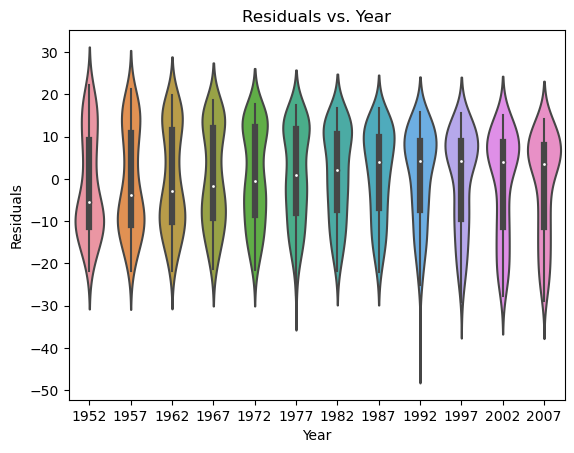

```python
r_df = pd.DataFrame({'residuals': lr.resid, 'year': data['year']})
data['residuals'] = r_df['residuals']
sns.violinplot(x='year', y='residuals', data=r_df)
plt.xlabel("Year")
plt.ylabel("Residuals")
plt.title("Residuals vs. Year")
plt.show()
```

### Boxplot: Visualizing Model Residuals by Continent

This boxplot visualizes the distribution of model residuals for each continent, helping us identify whether the model's prediction errors differ systematically by region. It highlights differences in median residuals, spread, and potential outliers across continents.

How the Code Works:

- To make a box plot of residuals versus continent, we first need to identify the dataset were using, along with what columns represent the independent variable and dependent variable. In this case, the DataFrame 'data' is our dataset, it's column 'continent' will represent the continent (the indepedent variable x), and it's column 'residuals' will represent the residuals (the dependent variable y).
- Next, we make use of Seaborn's 'boxplot' method, which takes in three arguments: data (we'll pass in the DataFrame 'data' for this value), 'x' (we'll pass in the column 'continent' for this value), and 'y' (we'll pass in the column 'residuals' for this value)
- Calling this method with the specified arguments mentioned above will display the desired box plot.
- Use Matplotlib's xlabel(), ylabel(), and title() functions to label the axes and add a title to the plot.
- Finally, call plt.show() to render and display the scatterplot.

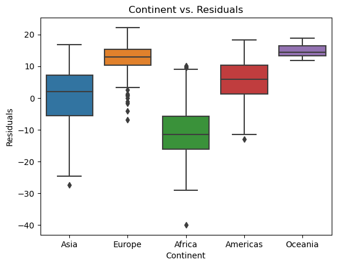

```python
sns.boxplot(data=data, x='continent', y='residuals')
plt.xlabel("Continent")
plt.ylabel("Residuals")
plt.title("Continent vs. Residuals")
plt.show()
```

#### Dependence between Model Residuals and Continent - Implications for Regression

There appears to be a dependence between model residual and continent as each box plot (for each continent) appears visibly different from one another. Africa's IQR (which is the lowest IQR (Inner Quartile Range) out of all these continents) has an upper bound that is smaller than Asia's IQR's lower bound (Asia has the second lowerest IQR). Additionally, the Americas' IQR is noticeably greater than Asia's, and Europe's and Oceania's IQR is noticeably greater than the Americas'. It's also important to note that all the continents (besides Europe and Oceania in relation to each other) have visibly different medians from one another. The two continents that show the most consistency also have distinctions between them as Europe has a noticeably greater amount of outliers than Oceania does. For all these reasons, it appears to be that residuals are in fact dependent on continent.

Since a dependence appears to exist between residuals and continent, that suggest that when performing a regression analysis of life expectancy across time, this linear regression model by itself may not be enough to fully describe the variation of the data. There appears to now be another variable, 'continent', which also significantly influences life expectancy. If the dependence between residuals and continent is statistically significant enough, then a new linear regression model should be made taking into account 'continent' in some way.

### Scatter Plot: Life Expectancy vs. Year by Continent with Regression Lines

This scatter plot visualizes how life expectancy changes over time for each continent, highlighting trends within each region. Adding regression lines helps illustrate the overall relationship between year and life expectancy and allows easy comparison of these trends across continents.

How the code works:

- First, we need to create separate DataFrames that contains only rows for a specific continent (Asia, Africa, Americas, Europe, Oceania). One DataFrame should be created for each continent. Here, we use boolean indexing to make the appropriate DataFrame filters.
- To make a scatter plot of life expectancy versus year for each continent, we first need to identify the datasets were using, along with what columns represent the independent variable and dependent variable. In this case, the DataFrames 'df_asia', 'df_africa', 'df_americas', 'df_europe', and 'df_oceania' will be used, one for each function call of 'lmplot()', the column 'year' will represent the year (the indepedent variable x), and it's column 'lifeExp' will represent the life expectancy (the dependent variable y).
- Next, we make use of Seaborn's 'lmplot()' method, which takes in three arguments: data (we'll pass in one of the DataFrame's mentioned for this value, respectively), 'x' (we'll pass in the column 'year' for this value), and 'y' (we'll pass in the column 'lifeExp' for this value)
  - NOTE --> 'lmplot()' is the function we'll be using to display scatter plots because it automatically also displays a linear regression line.
- Calling this method with the specified arguments mentioned above will display the desired scatter plot with a linear regression line
- One last plot will also be shown, which is all five plots for each continent combined into one plot. This will help better compare the plots.
- To do this, we call 'lmplot()' with the same x and y arguments mentioned above, however this time:
  - data=data, since were plotting all the data points for all the continents.
  - hue=continent, since we want different continents to have different colored points and different linear regression lines.
- Use Matplotlib's xlabel(), ylabel(), and title() functions to label the axes and add a title to the plot.
- Finally, call plt.show() to render and display the scatterplot.

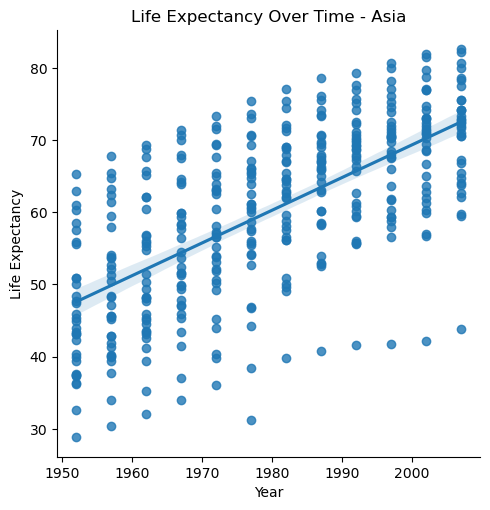

```python
df_asia = data[data['continent'] == 'Asia']
sns.lmplot(data=df_asia, x='year', y='lifeExp')
plt.xlabel("Year")
plt.ylabel("Life Expectancy")
plt.title("Life Expectancy Over Time - Asia")
plt.show()
```

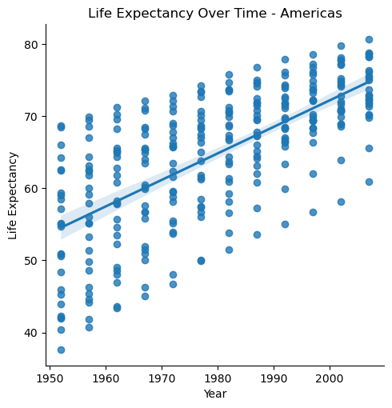

```python
df_americas = data[data['continent'] == 'Americas']
sns.lmplot(data=df_americas, x='year', y='lifeExp')
plt.xlabel("Year")
plt.ylabel("Life Expectancy")
plt.title("Life Expectancy Over Time - Americas")
plt.show()
```

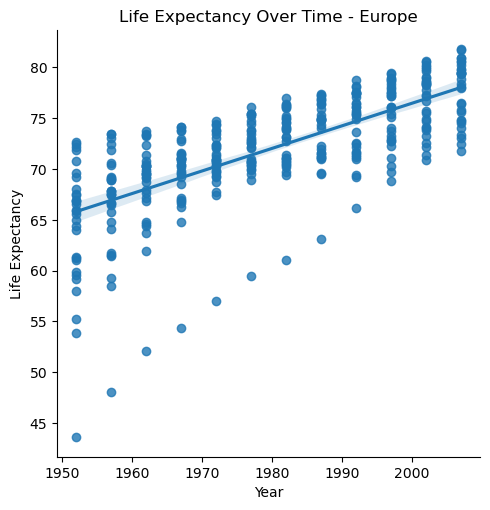

```python
df_europe = data[data['continent'] == 'Europe']
sns.lmplot(data=df_europe, x='year', y='lifeExp')
plt.xlabel("Year")
plt.ylabel("Life Expectancy")
plt.title("Life Expectancy Over Time - Europe")
plt.show()
```

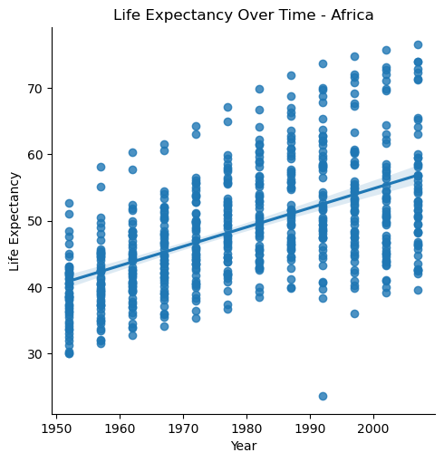

```python
df_africa = data[data['continent'] == 'Africa']
sns.lmplot(data=df_africa, x='year', y='lifeExp')
plt.xlabel("Year")
plt.ylabel("Life Expectancy")
plt.title("Life Expectancy Over Time - Africa")
plt.show()
```

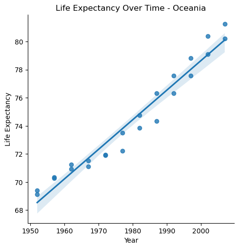

```python
df_oceania = data[data['continent'] == 'Oceania']
sns.lmplot(data=df_oceania, x='year', y='lifeExp')
plt.xlabel("Year")
plt.ylabel("Life Expectancy")
plt.title("Life Expectancy Over Time - Oceania")
plt.show()
```

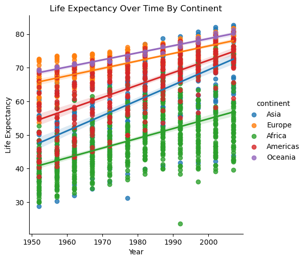

```python
sns.lmplot(data=data, x='year', y='lifeExp', hue='continent')
plt.xlabel("Year")
plt.ylabel("Life Expectancy")
plt.title("Life Expectancy Over Time By Continent")
plt.show()
```

### Fitting a Linear Regression Model: Life Expectancy vs. Year

#### Including an Interaction term between Continent and Year

These steps fit a linear regression model that accounts for both the individual effects of year and continent on life expectancy, as well as how those effects interact. Including the interaction term helps capture differences in life expectancy trends over time across continents.

How the Code Works:

- Call sm's method 'ols()' to create a model from a formula and a DataFrame object.
- Pass in the appropriate arguments in the proper format:
  - To model life expectancy including the interaction term continent:year, pass in the following to formula: "lifeExp ~ continent + year + continent:year"
    - formula argument is the formula specifying the model.
  - Pass in 'data' for data argument, as that's the data being used for the model
- This returns the model instance, which we then can call the method 'fit()' on to properly fit the model
- Store the result of 'fit()' in a variable called 'lr2'
- Call lr2's method 'summary()' which calculates the useful summary statistics that tell us whether or not this is a good fit, print these results.

```python
lr2 = sm.ols(formula="lifeExp ~ continent + year + continent:year", data=data).fit()
print(lr2.summary())
```

```
                            OLS Regression Results
==============================================================================
Dep. Variable:                lifeExp   R-squared:                       0.693
Model:                            OLS   Adj. R-squared:                  0.691
Method:                 Least Squares   F-statistic:                     424.3
Date:                Sun, 22 Jun 2025   Prob (F-statistic):               0.00
Time:                        20:06:05   Log-Likelihood:                -5771.9
No. Observations:                1704   AIC:                         1.156e+04
Df Residuals:                    1694   BIC:                         1.162e+04
Df Model:                           9
Covariance Type:            nonrobust
==============================================================================================
                                 coef    std err          t      P>|t|      [0.025      0.975]
----------------------------------------------------------------------------------------------
Intercept                   -524.2578     32.963    -15.904      0.000    -588.911    -459.605
continent[T.Americas]       -138.8484     57.851     -2.400      0.016    -252.315     -25.382
continent[T.Asia]           -312.6330     52.904     -5.909      0.000    -416.396    -208.870
continent[T.Europe]          156.8469     54.498      2.878      0.004      49.957     263.737
continent[T.Oceania]         182.3499    171.283      1.065      0.287    -153.599     518.298
year                           0.2895      0.017     17.387      0.000       0.257       0.322
continent[T.Americas]:year     0.0781      0.029      2.673      0.008       0.021       0.135
continent[T.Asia]:year         0.1636      0.027      6.121      0.000       0.111       0.216
continent[T.Europe]:year      -0.0676      0.028     -2.455      0.014      -0.122      -0.014
continent[T.Oceania]:year     -0.0793      0.087     -0.916      0.360      -0.249       0.090
==============================================================================
Omnibus:                       27.121   Durbin-Watson:                   0.242
Prob(Omnibus):                  0.000   Jarque-Bera (JB):               44.106
Skew:                          -0.121   Prob(JB):                     2.65e-10
Kurtosis:                       3.750   Cond. No.                     2.09e+06
==============================================================================

Notes:
[1] Standard Errors assume that the covariance matrix of the errors is correctly specified.
[2] The condition number is large, 2.09e+06. This might indicate that there are
strong multicollinearity or other numerical problems.
```

#### Model Parameter Significance

Not all parameters in the model are significantly different from zero because when looking at the p-values associated with each coefficient in the model, at least one of them is greater than 0.05 (the level of significance). We can see this by looking at the output of lr2.summary() printed above. Specifically:

| Continent | p-value | Comparison to 0.05 | Statistically Significant? |
| --- | --- | --- | --- |
| Africa | 0.000 | < 0.05 | Yes |
| Americas | 0.008 | < 0.05 | Yes |
| Asia | 0.000 | < 0.05 | Yes |
| Europe | 0.014 | < 0.05 | Yes |
| Oceania | 0.360 | > 0.05 | No |

The parameter representing Oceania is NOT statistically significant, and thus it is NOT significantly different from zero.

#### Annual Change in Life Expectancy by Continent

Based on the OLS regression results, to find out how much life expectancy increases each year for continent, we can look at the coefficients associated with each continent. Specifically:

[output not shown]

### Comparing Model Fits: F-Test for Interaction Between Year and Continent

The two models to be compared are:

- Linear Regression Model w/ only year as a covariate
- Linear Regression Model including interaction between year and continent

This section compares two linear regression models to determine whether including an interaction term between year and continent significantly improves model fit. An F-test is used to assess whether the more complex model explains significantly more variance in life expectancy than the simpler model.

#### Linear Regression Model Using Only Year as Predictor

```python
print(lr.summary())
```

```
                            OLS Regression Results
==============================================================================
Dep. Variable:                lifeExp   R-squared:                       0.190
Model:                            OLS   Adj. R-squared:                  0.189
Method:                 Least Squares   F-statistic:                     398.6
Date:                Sun, 22 Jun 2025   Prob (F-statistic):           7.55e-80
Time:                        20:06:05   Log-Likelihood:                -6597.9
No. Observations:                1704   AIC:                         1.320e+04
Df Residuals:                    1702   BIC:                         1.321e+04
Df Model:                           1
Covariance Type:            nonrobust
==============================================================================
                 coef    std err          t      P>|t|      [0.025      0.975]
------------------------------------------------------------------------------
Intercept   -585.6522     32.314    -18.124      0.000    -649.031    -522.273
year           0.3259      0.016     19.965      0.000       0.294       0.358
==============================================================================
Omnibus:                      386.124   Durbin-Watson:                   0.197
Prob(Omnibus):                  0.000   Jarque-Bera (JB):               90.750
Skew:                          -0.268   Prob(JB):                     1.97e-20
Kurtosis:                       2.004   Cond. No.                     2.27e+05
==============================================================================

Notes:
[1] Standard Errors assume that the covariance matrix of the errors is correctly specified.
[2] The condition number is large, 2.27e+05. This might indicate that there are
strong multicollinearity or other numerical problems.
```

#### Linear Regression Model Using Year and Year-by-Continent Interaction as Predictors

```python
print(lr2.summary())
```

```
                            OLS Regression Results
==============================================================================
Dep. Variable:                lifeExp   R-squared:                       0.693
Model:                            OLS   Adj. R-squared:                  0.691
Method:                 Least Squares   F-statistic:                     424.3
Date:                Sun, 22 Jun 2025   Prob (F-statistic):               0.00
Time:                        20:06:05   Log-Likelihood:                -5771.9
No. Observations:                1704   AIC:                         1.156e+04
Df Residuals:                    1694   BIC:                         1.162e+04
Df Model:                           9
Covariance Type:            nonrobust
==============================================================================================
                                 coef    std err          t      P>|t|      [0.025      0.975]
----------------------------------------------------------------------------------------------
Intercept                   -524.2578     32.963    -15.904      0.000    -588.911    -459.605
continent[T.Americas]       -138.8484     57.851     -2.400      0.016    -252.315     -25.382
continent[T.Asia]           -312.6330     52.904     -5.909      0.000    -416.396    -208.870
continent[T.Europe]          156.8469     54.498      2.878      0.004      49.957     263.737
continent[T.Oceania]         182.3499    171.283      1.065      0.287    -153.599     518.298
year                           0.2895      0.017     17.387      0.000       0.257       0.322
continent[T.Americas]:year     0.0781      0.029      2.673      0.008       0.021       0.135
continent[T.Asia]:year         0.1636      0.027      6.121      0.000       0.111       0.216
continent[T.Europe]:year      -0.0676      0.028     -2.455      0.014      -0.122      -0.014
continent[T.Oceania]:year     -0.0793      0.087     -0.916      0.360      -0.249       0.090
==============================================================================
Omnibus:                       27.121   Durbin-Watson:                   0.242
Prob(Omnibus):                  0.000   Jarque-Bera (JB):               44.106
Skew:                          -0.121   Prob(JB):                     2.65e-10
Kurtosis:                       3.750   Cond. No.                     2.09e+06
==============================================================================

Notes:
[1] Standard Errors assume that the covariance matrix of the errors is correctly specified.
[2] The condition number is large, 2.09e+06. This might indicate that there are
strong multicollinearity or other numerical problems.
```

#### Perform the F-Test

When performing an F-test, we want to compare the F-statistic for the two models mentioned. The 'summary()' called above printed the summary statistics for each linear regression model. We will reference those statistics.

- F-statistic (Linear Regression Model w/ only year as a covariate) = 398.6
- F-statistic (Linear Regression Model including interaction between year and continent) = 424.3

Since both these F-statistics are high, both models can be deemed as being good fits. However, since 424.3 > 398.6, the linear regression model including the interaction between year and continent is a better fit than the other model. Additionally, p-value associated with the F-statistic of the linear regression model including the interaction between year and continent is lower than the other models F-statistic p-value. For both of these reasons we can say that the interaction model is a significantly better fit than the year-only model.

### Violin Plot: Residuals vs. Year for Interaction Model

Down below is the code needed to create a residuals versus year violin plot for the interaction model. This is important to do because it helps visually assess whether the key assumptions of linear regression, such as normality, independence, and constant variance of residuals, are met.

The plot seems to match the assumptions of the linear regression model quite well. The median values of all the residuals are tending to stick around zero (maintaining the constant variance assumption), and the clustering seems to be equally distributed above and below the mean value of 0 (maintaining the independent error assumption). Additionally, each violin within the violin plot appears to be normally distributed, which also follows residual assumptions.

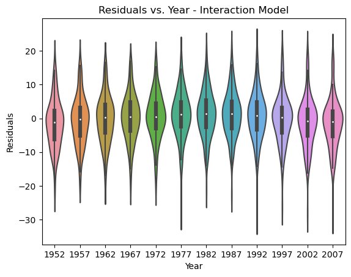

```python
r_df = pd.DataFrame({'residuals': lr2.resid, 'year': data['year']})
sns.violinplot(x='year', y='residuals', data=r_df)
plt.xlabel("Year")
plt.ylabel("Residuals")
plt.title("Residuals vs. Year - Interaction Model")
plt.show()
```

Checking residuals versus fitted values is also important to verify key assumptions of the linear regression model.

How the Code Works:

- Reshape the year column so it's in the proper format to predict values (Use NumPy's 'array().reshape()' method).
- Use OLS_Model's predictor() method to predict the average life expectancy values by year.
- To make a violin plot of residuals versus fitted/predicted values (pv), we first need to identify the dataset we're using, along with what were using to represent the independent variable and dependent variable. In this case, the DataFrame 'r_df' is our dataset, the ndarray 'pv' will represent the fitted value (the indepedent variable x), and the datasets column 'residuals' will represent the residuals (the dependent variable y).
- plt.figure() creates a new figure with a specified width of 12 inches and height of 6 inches, setting the size of the overall plot.
- Next, we make use of Seaborn's 'violinplot' method, which takes in three arguments: data (we'll pass in the DataFrame 'r_df' for this value), 'x' (we'll pass in the 'pv' for this value), and 'y' (we'll pass in the column 'residuals' for this value)
- plt.xticks() rotates the x-axis tick labels by 45 degrees to make them easier to read, especially when the labels are long or crowded.
- Calling this method with the specified arguments mentioned above will display the desired violin plot.

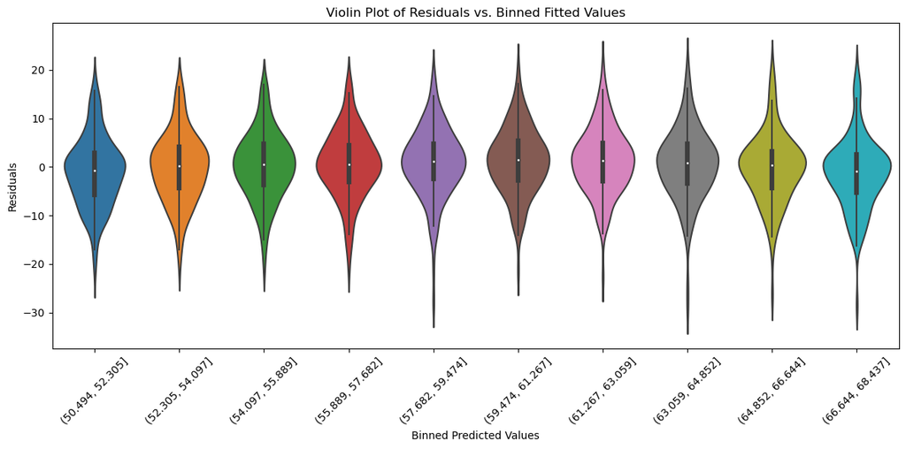

```python
yr = np.array(data['year']).reshape(-1, 1)
pv = OLS_model.predict(yr)
r_df['predicted'] = pv
r_df['predicted_bin'] = pd.cut(r_df['predicted'], bins=10)

plt.figure(figsize=(12, 6))
sns.violinplot(x='predicted_bin', y='residuals', data=r_df)
plt.xticks(rotation=45)
plt.xlabel('Binned Predicted Values')
plt.ylabel('Residuals')
plt.title('Violin Plot of Residuals vs. Binned Fitted Values')
plt.tight_layout()
plt.show()
```